# R Review

Christelinda Laureijs

June 20, 2024

Here are some chunks and code examples if you need a refresher with R.

```r
# You can use R as a calculator
2+3
```

```
## [1] 5
```

```r
3*5
```

```
## [1] 15
```

```r
2/5
```

```
## [1] 0.4
```

```r
# You can assign values to variables
# Make x equal to 2
x <- 2

# Use variables in equations
3*x
```

```
## [1] 6
```

```r
x + 2
```

```
## [1] 4
```

```r
# Defining lists in R

number_list <- c(1, 9, 8, 3, 4, 2, 2)


# Use functions like mean()
mean(number_list)
```

```
## [1] 4.142857
```

```r
max(number_list)
```

```
## [1] 9
```

```r
min(number_list)
```

```
## [1] 1
```

## Importing data

The following sample code is for a project where the goal was to analyze changes in a neuron’s current amplitude over time.

```r
# Import cell data from "Sample-data.csv"
# This comes from the folder Data/
# Header = True because I already have named my columns

raw_df <- read.csv(here("Data/Sample-data.csv"), header = T)
```

```r
# Get a preview of the first few rows of the data
head(raw_df)
```

|  | Letter | Synapses | Sex | Treatment | Time | ID | P1 | P2 | X | Y | Age | Animal | Category | Cell |
| --- | --- | --- | --- | --- | --- | --- | --- | --- | --- | --- | --- | --- | --- | --- |
| 1 | AA | Glutamate | Male | Control | 0.00000000 | 23615004 | -136.429642 | -137.65034 | 165.2897 | 215.6294 | 31 | 13 | 2 | 13.2.1 |
| 2 | AA | Glutamate | Male | Control | 0.08333333 | 23615004 | -5.372700 | -40.77309 | 165.2897 | 215.6294 | 31 | 13 | 2 | 13.2.1 |
| 3 | AA | Glutamate | Male | Control | 0.16666667 | 23615004 | -49.928364 | -124.39126 | 165.2897 | 215.6294 | 31 | 13 | 2 | 13.2.1 |
| 4 | AA | Glutamate | Male | Control | 0.25000000 | 23615004 | -8.175499 | -29.53780 | 165.2897 | 215.6294 | 31 | 13 | 2 | 13.2.1 |
| 5 | AA | Glutamate | Male | Control | 0.33333333 | 23615004 | -8.785851 | -10.00655 | 165.2897 | 215.6294 | 31 | 13 | 2 | 13.2.1 |
| 6 | AA | Glutamate | Male | Control | 0.41666667 | 23615004 | -79.875748 | -76.82399 | 165.2897 | 215.6294 | 31 | 13 | 2 | 13.2.1 |

```r
# Clampex records negative values for currents
# Negative transform P1 and P2

raw_df <- raw_df %>%
  mutate(
    P1 = P1*-1,
    P2 = P2*-1
  )
```

## Filter data

```r
# Show cells from male rats only

raw_df %>%
  filter(Sex == "Male")
```

| Letter | Synapses | Sex | Treatment | Time | ID | P1 | P2 | X | Y | Age | Animal | Category | Cell |
| --- | --- | --- | --- | --- | --- | --- | --- | --- | --- | --- | --- | --- | --- |
| AA | Glutamate | Male | Control | 0.00000000 | 23615004 | 136.42964170 | 137.650344800 | 165.2897 | 215.6294 | 31 | 13.0 | 2 | 13.2.1 |
| AA | Glutamate | Male | Control | 0.08333333 | 23615004 | 5.37269974 | 40.773090360 | 165.2897 | 215.6294 | 31 | 13.0 | 2 | 13.2.1 |
| AA | Glutamate | Male | Control | 0.16666667 | 23615004 | 49.92836380 | 124.391258200 | 165.2897 | 215.6294 | 31 | 13.0 | 2 | 13.2.1 |
| AA | Glutamate | Male | Control | 0.25000000 | 23615004 | 8.17549896 | 29.537803650 | 165.2897 | 215.6294 | 31 | 13.0 | 2 | 13.2.1 |
| AA | Glutamate | Male | Control | 0.33333333 | 23615004 | 8.78585053 | 10.006553650 | 165.2897 | 215.6294 | 31 | 13.0 | 2 | 13.2.1 |
| AA | Glutamate | Male | Control | 0.41666667 | 23615004 | 79.87574768 | 76.823989870 | 165.2897 | 215.6294 | 31 | 13.0 | 2 | 13.2.1 |
| AA | Glutamate | Male | Control | 0.50000000 | 23615004 | 118.09499360 | 33.256130220 | 165.2897 | 215.6294 | 31 | 13.0 | 2 | 13.2.1 |
| AA | Glutamate | Male | Control | 0.58333333 | 23615004 | 7.70167303 | 66.905776980 | 165.2897 | 215.6294 | 31 | 13.0 | 2 | 13.2.1 |
| AA | Glutamate | Male | Control | 0.66666667 | 23615004 | 30.58182526 | 32.412879940 | 165.2897 | 215.6294 | 31 | 13.0 | 2 | 13.2.1 |
| AA | Glutamate | Male | Control | 0.75000000 | 23615004 | 50.61902618 | 117.757698100 | 165.2897 | 215.6294 | 31 | 13.0 | 2 | 13.2.1 |

[output cut: 6797 more lines]

## Dealing with errors

R is very picky about typos, upper-case vs. lower-case, and other details. What are the mistakes below?

```r
# What is the mistake below?
raw_df %>%
   filter(sex == "Male")
```

```r
# What is the problem below?
raw_df %>%
  filter(Sex = "Female")
```

```r
# What is wrong with the code below?
raw_df %>%
  filter(Sex == "Female"')
```

## Plotting

The goal is to make a scatterplot of P1 vs. Time for various cells. First, I am showing an example of plotting filtering just one recording of interest. This has the ID “L”.

```r
# Filter one recording of interest
cell_L <- raw_df %>%
  filter(Letter == "L")
```

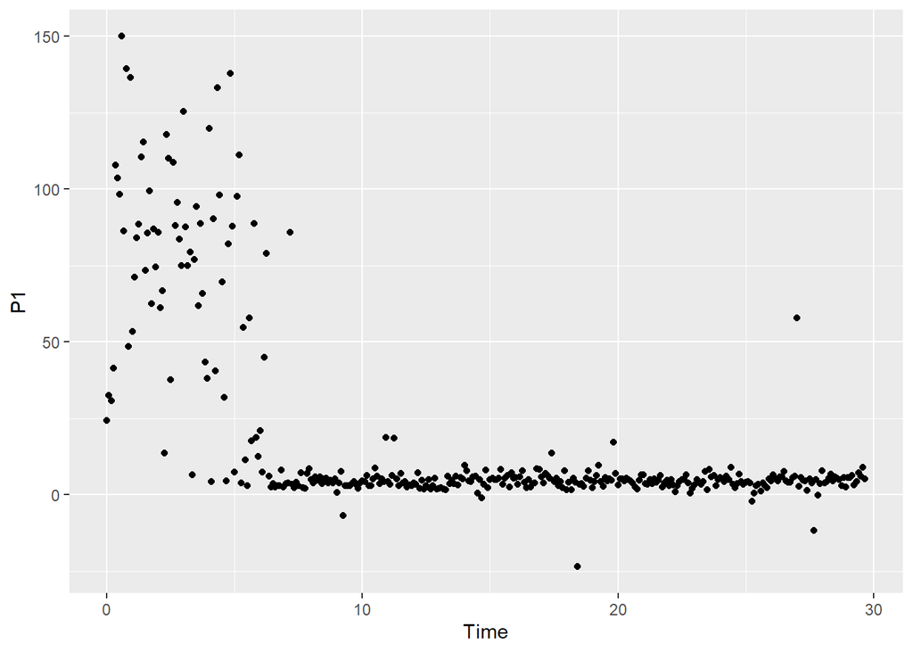

```r
# Plot cell L only
# P1 is on the y-axis
# Time is on the x-axis
# Use geom_point() because this is a scatterplot

ggplot(cell_L, aes(x = Time, y = P1)) +
  geom_point()
```

To add customizations to your plot, you can keep adding new layers. The first layer that I’m adding here is the labs() layer to make more informative axis titles.

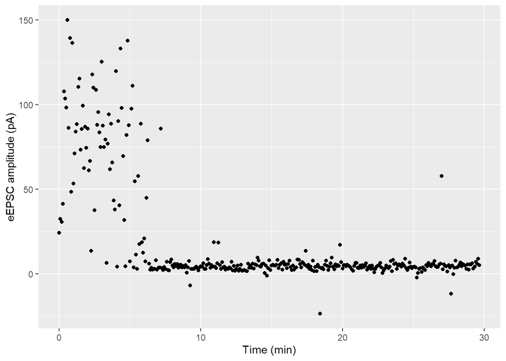

```r
# Example: adding better axis labels
ggplot(cell_L, aes(x = Time, y = P1)) +
  geom_point() +
  labs(
    x = "Time (min)",
    y = "eEPSC amplitude (pA)"
  )
```

I recorded cells in 5-minute intervals. I included `color = ID` to colour each recording separately. This is just to show an example of how you can include additional variables in a plot.

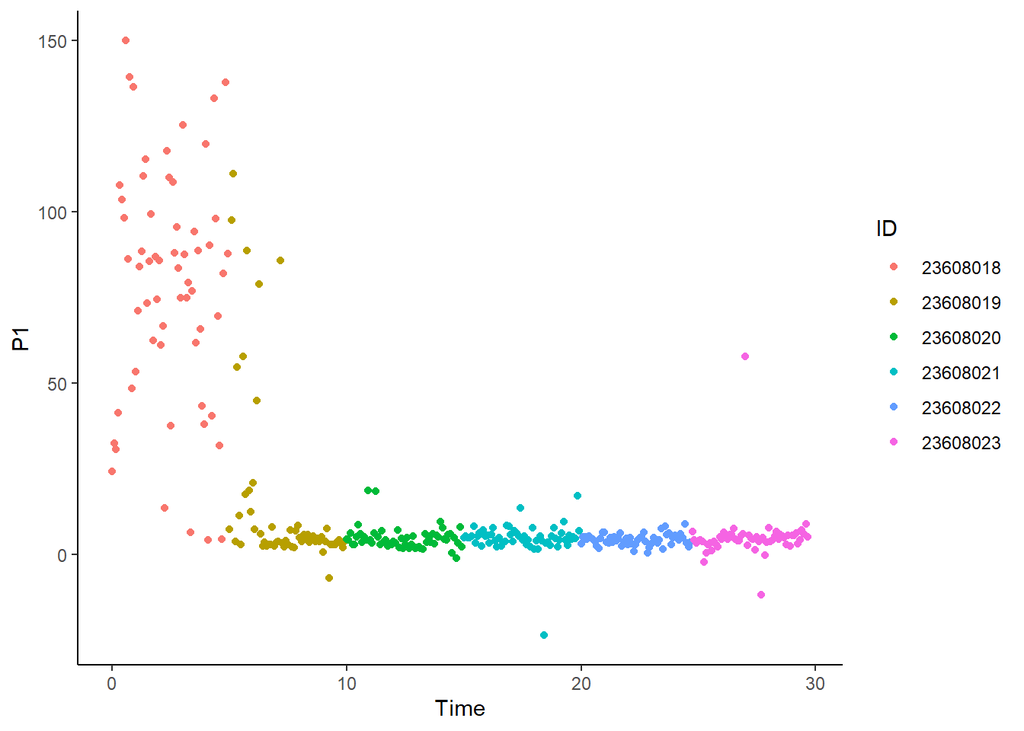

```r
# Color by ID
ggplot(cell_L, aes(x = Time, y = P1, color = ID)) +
  geom_point() +
  theme_classic()
```

You can use `ggplot` to make beautiful plots very easily. Here are some examples that show some of ggplot’s capabilities.

The plot below shows the data for all of my cells on the same plot. I used `color = Letter` to make each cell a different colour.

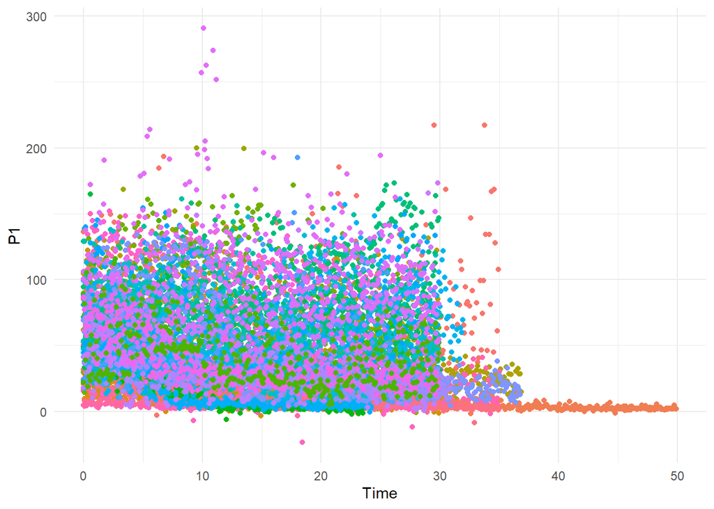

```r
# Plot all cells
# Use a different color for each recording

ggplot(raw_df, aes(x = Time, y = P1, color = Letter)) +
  geom_point() +
  theme_minimal() +
  theme(legend.position = "none") # hide legend
```

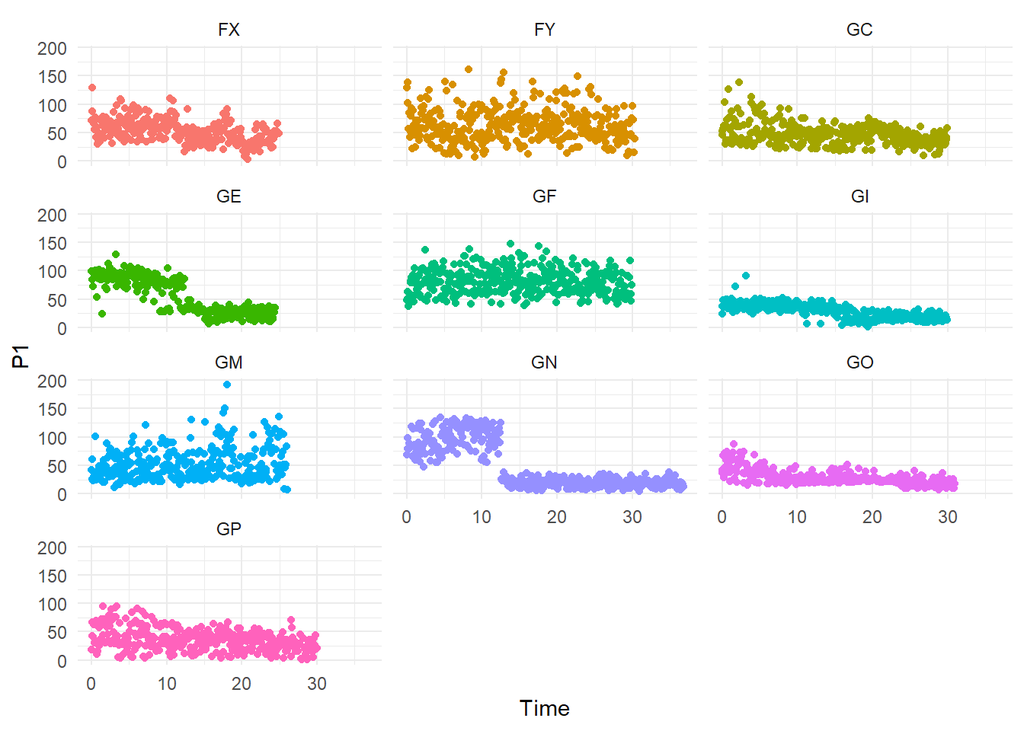

```r
raw_df %>%
  filter(Sex == "Female" & Treatment == "PPP") %>%
  ggplot(aes(x = Time, y = P1, color = Letter)) +
  geom_point() +
  theme_minimal() +
  theme(legend.position = "none") +
  facet_wrap(.~Letter, ncol = 3)
```

### Plot Customization

Often you’ll want to change the default ggplot themes and colours. To save yourself from retyping the same style changes for each plot, you can define a theme that will be applied to all ggplot2 themes. You should experiment to find a ggplot theme that works for your project, but here is one example that could work well for a publication. This theme increases the axis font sizes and removes the default gray background.

```r
theme_set(
  theme_classic() %+replace%
    theme(
        plot.title = element_text(
        color = "black",
        size = 20,
        margin = margin(b = 25),
        hjust = 0.5
      ),
      plot.margin = margin(25, 25, 25, 25),
      plot.caption = element_text(
        hjust = 0,
        size = 12
      ),
      plot.caption.position = "plot",
      axis.text = element_text(
        size = 12,
        color = "black"
      ),
      axis.title = element_text(
        size = 16,
        face = "bold"
      ),
      axis.title.y = element_text(
        margin = margin(r = 25),
        angle = 90,
        vjust = 0.5
      ),
      axis.title.x = element_text(margin = margin(b = 25, t = 20)),
      axis.ticks = element_blank(),
      strip.background = element_rect(color = NA, fill = NA),
      strip.text = element_text(size = 20)
    )
)

plot_colour <- "darkmagenta"
```

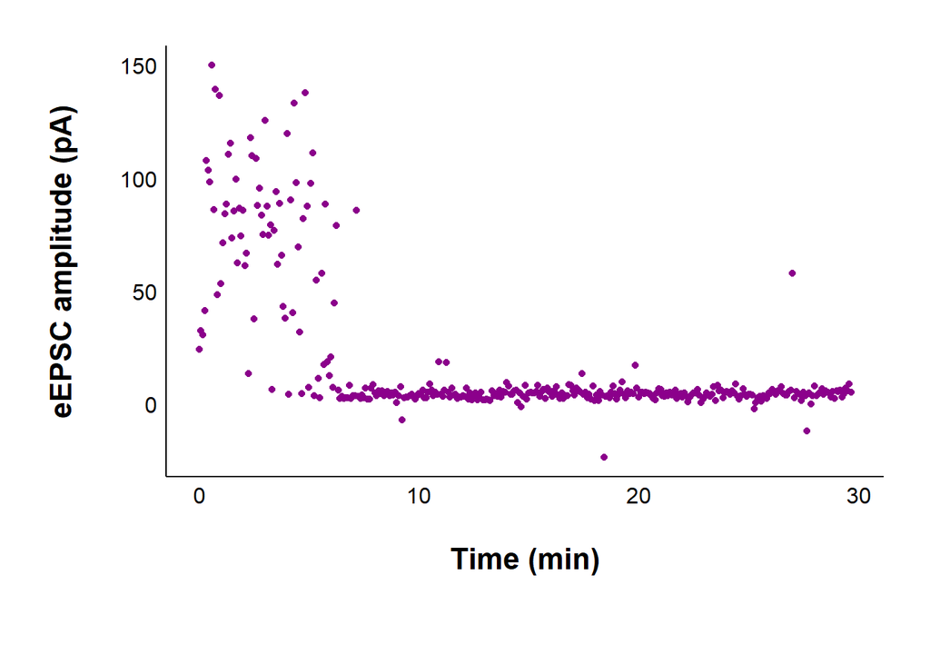

```r
ggplot(cell_L, aes(x = Time, y = P1)) +
  geom_point(color = plot_colour) +
  labs(
    x = "Time (min)",
    y = "eEPSC amplitude (pA)"
  )
```

## Practice

If you want some extra practice, try changing the code and seeing what happens. You can also try these questions.

1a. Create a variable called “y” and assign it to a value of 25. 1b. Use a function to calculate the square root of y.

2a. Filter the data to only include cells where I applied a certain treatment. 2b. Filter the data to only include cells from male rats in the control condition. (Hint: Use the & symbol to connect two conditions).

3a. Make a plot of P1 vs. Time for recording “AA”. 3b. Make a plot of P1 vs. Time for female rats only. 3c. Make a plot of P1 vs. Time for PPP-treated cells only, and color it by cell.